# Barbell Lifts R Analysis

Patrick Machado

### Introduction

The goal for this analysis is to predict the manner in which the participants of the experiment did the exercise. This is the “classe” variable in the training set, available in: https://d396qusza40orc.cloudfront.net/predmachlearn/pml-training.csv.

The prediction model constructed will be used to predict 20 different test cases, from the test data available here: https://d396qusza40orc.cloudfront.net/predmachlearn/pml-testing.csv.

The data for this project come from this source: http://groupware.les.inf.puc-rio.br/har.

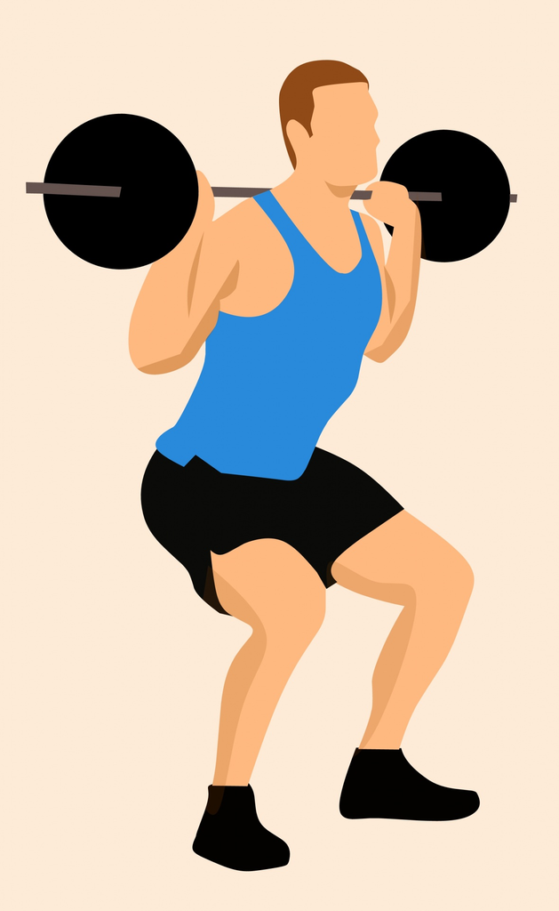

Barbell lifts!

Image from www.needpix.com.

### A. Loading and partitioning the data

#### A.1 Libraries loading

```r
library(caret)
library(ggplot2)
library(readr)
library(FSelector)
library(rpart)
library(GGally)
library(knitr)
```

#### A.2 Data reading from the web

The datasets has 160 variables each.

```r
training.raw <- read.csv('https://d396qusza40orc.cloudfront.net/predmachlearn/pml-training.csv') #19622x160
validation.raw <- read.csv('https://d396qusza40orc.cloudfront.net/predmachlearn/pml-testing.csv')    #20x160
```

```r
cat('Original Training dimensions: ', dim(training.raw),
    '\nOriginal Testing dimensions: ', dim(validation.raw))
```

```
Original Training dimensions:  19622 160
Original Testing dimensions:  20 160
```

### B. Exploratory analysis and data cleaning

#### B.1 Partitioning

It’s considered that the 19.622 data rows are enough to make two partitions, training (70%) and testing (30%).

```r
set.seed(4321)
inTrain <- createDataPartition(training.raw$classe, p = 7/10, list = FALSE)
training <- training.raw[ inTrain, ]
testing <- training.raw[ -inTrain, ]

cat('Model Training dimensions: ', dim(training),
    '\nModel Testing dimensions: ', dim(testing))
```

```
Model Training dimensions:  13737 160
Model Testing dimensions:  5885 160
```

#### B.2 Exploratory Analysis

After an exploratory analysis, some relevant facts about the data where found:

- There are some columns for identification and for the timestamp of the data, like `X`, `user_name`, `raw_timestamp_part_1`, `raw_timestamp_part_2`, and `cvtd_timestamp`.
- Appears that the `num_window` variable was intended for the experimental design, as can be seen in the following figure, that shows the relation between the `user_name`, `num_window` and `classe` variables.

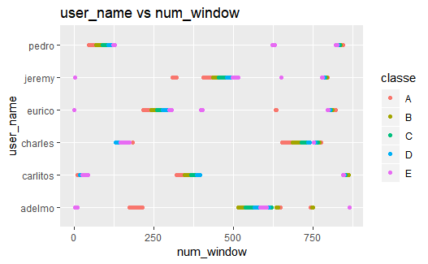

```r
qplot(training[, 'num_window'], training[, 'user_name'],
      data = training, colour = classe,
      ylab = 'user_name', xlab = 'num_window',
      main = 'user_name vs num_window')
```

- The categorial variable `new_window` is very biased and split the data into two groups: no: 97.9% / yes: 2.1%

```r
summary(training$new_window)
```

```
   no   yes
13447   290
```

```r
summary(training$new_window) / nrow(training) *100
```

```
       no       yes
97.888913  2.111087
```

- There are some variables where in the 97.9% of the cases there isn’t useful data, for instance `kurtosis_roll_belt`, `kurtosis_picth_belt`, and `avg_pitch_forearm`:

```r
summary(training[, c('kurtosis_roll_belt', 'kurtosis_picth_belt', 'avg_pitch_forearm')])
```

```
 kurtosis_roll_belt kurtosis_picth_belt
          :13447             :13447
 #DIV/0!  :    8    #DIV/0!  :   26
 -1.908453:    2    47.000000:    4
 -0.016850:    1    -0.684748:    3
 -0.021024:    1    -1.750749:    3
 -0.025513:    1    -2.060105:    3
 (Other)  :  277    (Other)  :  251
 avg_pitch_forearm
 Min.   :-68.17
 1st Qu.:  0.00
 Median : 12.10
 Mean   : 11.56
 3rd Qu.: 25.45
 Max.   : 72.09
 NA's   :13447
```

#### B.3 Data Exclusion

According to the previous analysis, some variables are going to be excluded for the main model construction:

- Because they are don’t bring actual data measured from the sensors, and are intended for identification or experimental design only
- Because they have too little data, just in the 2.1% of the measurings

In the following chunk, there is the code for filtering those variables, resulting in 107 less features to build the model.

```r
# Without enough data
sumary0 <- summary(training)
sin.datos <- parse_number(sumary0[ 1, ]) == 13447 |
  parse_number(sumary0[ 7, ]) == 13447

sin.datos[ is.na(sin.datos)] <- FALSE
sin.datos <- colnames(sumary0)[sin.datos]

# Identification variables
sin.datos <- append(c('      X', '   user_name', 'raw_timestamp_part_1',
                      'raw_timestamp_part_2', '         cvtd_timestamp',
                      '  num_window'), sin.datos)

# Column Numbers to exclude
sin.datos.num <- which(colnames(sumary0) %in% sin.datos)
cat('Excluded variables: ', length(sin.datos.num))
```

```
Excluded variables:  107
```

### C. Main Features selection

Excluding the previous 107 variables, there are still `160 - 107 - 1 =` **`52`** variables that can be used for the model building. In order to simplifying the model and avoid overfitting, an analysis with the **FSelector** library is accomplished, that select the main features using correlation and entropy measures and resulting in the following formula:

```r
main.features <- cfs(classe ~ . , data = training[, -sin.datos.num])
main.formula <- as.simple.formula( main.features, "classe" )
main.formula
```

```
classe ~ roll_belt + pitch_belt + yaw_belt + magnet_arm_x + gyros_dumbbell_y +
    magnet_dumbbell_y + pitch_forearm
<environment: 0x00000245411a2ac8>
```

Below is the relationship between the seven variables suggested for the **FSelector** package.

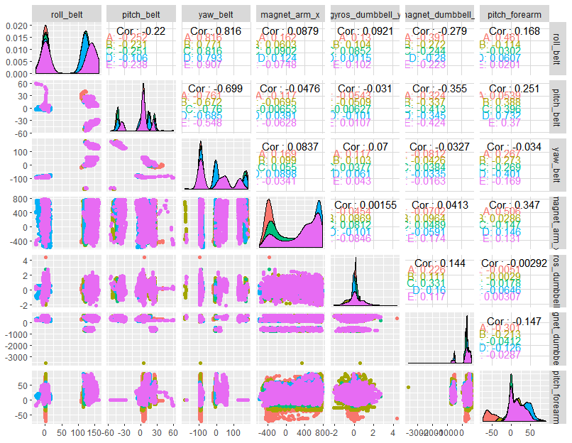

```r
# Versión con colores
f.pairs.col <- ggpairs(data = training, columns =
                         main.features,
                       aes(colour = classe))
f.pairs.col
```

### D. Models construction

Six different models are going to be constructed, to compare the accuracy vs the number of predictors and the method selected.

- The first three use just one predictor, the `num_window` variable. This models are for reference, because in a real prediction scenary, with just the data that comes directly from the sensors, this variable is hardly going to be available.
- Models four and five use the seven variables showed above
- The last model use 52 predictors, excluding the variables analysed previously in the B.3 chapter

[output not shown]

```r
# D.1 Models with num_window
model.num_window.rf <- train(classe ~ num_window, data =
                               training, method = "rf")

model.num_window.knn <- train(classe ~ num_window, data =
                                training, method = "knn")

model.num_window.rpart <- rpart(classe ~ num_window, data =
                                  training, method = "class")

# D.2 Model knn with 7 features: Train acc: .67
model.main.knn <- train(main.formula, data = training, method = "knn")

# D.3 Model rf with 7 features: Train acc: .97
model.main.rf <- train(main.formula, data = training, method = "rf")

# D.4 Model knn with 52 featuress: Train acc: .87
model.knn <- train(classe ~ ., data = training[, -sin.datos.num], method = "knn")
```

### E: Model validation

To validate the performance of the different models builded, the acuracy of the prediction against the testing dataset is meaured and presented in the following table.

```r
# Function for accuracy calculation
fxAccuracy <- function(model){
  if(model$method == 'class') {
    predict0 <- predict(model, type = "class",
                        newdata = testing)
  } else {
    predict0 <- predict(model, newdata = testing)
  }
  sum(predict0 == testing$classe) / nrow(testing)
}


# Accuracies calculation
accuracies <- sapply(list(model.num_window.rf,
                          model.num_window.knn,
            model.num_window.rpart, model.main.knn,
            model.main.rf, model.knn), fxAccuracy)
```

```r
kable(data.frame(Model_name = c('model.num_window.rf', 'model.num_window.knn', 'model.num_window.rpart', 'model.main.knn', 'model.main.rf', 'model.knn'),
                 Predictors = c(1, 1, 1, 7, 7, 52),
                 Accuracy = accuracies), digits = 4,
      format = "markdown")
```

| Model_name | Predictors | Accuracy |
| --- | --- | --- |
| model.num_window.rf | 1 | 0.9997 |
| model.num_window.knn | 1 | 0.9995 |
| model.num_window.rpart | 1 | 0.8449 |
| model.main.knn | 7 | 0.6977 |
| model.main.rf | 7 | 0.9796 |
| model.knn | 52 | 0.9023 |

```r
NA
```

### G. Prediction with the original test dataset

In the following chunk is the code for the prediction with the two random forest models mentioned above, the first one with just one ‘fake’ predictor and the other one with 7 predictors. Both present the same results.

```r
data.frame(RF_1_predictor = predict(model.num_window.rf,
                                  validation.raw),
            RF_7_predictors = predict(model.main.rf,
                                      validation.raw))
```

```
   RF_1_predictor RF_7_predictors
1               B               B
2               A               A
3               B               B
4               A               A
5               A               A
6               E               E
7               D               D
8               B               B
9               A               A
10              A               A
11              B               B
12              C               C
13              B               B
14              A               A
15              E               E
16              E               E
17              A               A
18              B               B
19              B               B
20              B               B
```